# The Rising Tides and Temperatures of San Francisco

Allie Hsu

12/3/2019

## Temperature Changes in San Francisco

San Francisco is a city very near my own, San Jose California. While it is surrounded on three sides by water, either from the ocean or the bay, it has always been a location that has been fixed in my mind as permanent and immoveable. It is one of the oldest cities in California with a multifaceted past of progress, domination, wealth and power. temperature changes since 1921 cannot be attributed to becoming a heat island, as it has been developed for over a century.

## Methods for Understanding San Francisco Climate Trends

I decided to use climate data on the maximum and minimum temperatures noted by a station in San Francisco daily in order to reflect a rising concern for environmental consequences. Climate data from across the planet is freely available from NOAA (National Oceanic and Atmospheric Administration). I downloaded data from a station in downtown San Francisco.

I used RStudio software to evaluate and represent the data. I filtered out outliers and created averages for the maximum and minimum temperatures (F) for each month between 1920 and 2020. I will be testing the null hypothesis that the slope of the best fit line on these linear models is zero, y-intercept is zero.

## Results - Analyse Climate Data

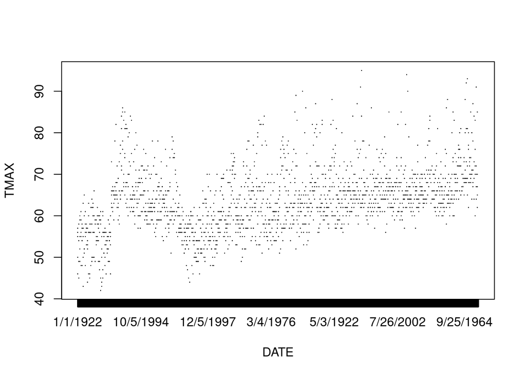

```r
plot(TMAX~DATE, climate_data[1:1835,], ty='l')
```

In this first plot, we see that the dates are oddly out of order. In order to fix this, we must make sure that the data is recognizeable as a date rather than as a random sequence of numbers. This will ensure that they show up in chronological order. We will fix this below:

```r
str(climate_data)
```

```
## 'data.frame':    35930 obs. of  26 variables:
##  $ STATION: Factor w/ 1 level "USW00023272": 1 1 1 1 1 1 1 1 1 1 ...
##  $ NAME   : Factor w/ 1 level "SAN FRANCISCO DOWNTOWN, CA US": 1 1 1 1 1 1 1 1 1 1 ...
##  $ DATE   : Factor w/ 35930 levels "1/1/1922","1/1/1923",..: 26823 27912 29001 29298 29397 29496 29595 29694 29793 26922 ...
##  $ DAPR   : int  NA NA NA NA NA NA NA NA NA NA ...
##  $ MDPR   : num  NA NA NA NA NA NA NA NA NA NA ...
##  $ PRCP   : num  0 0 0 0 0 0 0 0 0 0 ...
##  $ PSUN   : int  NA NA NA NA NA NA NA NA NA NA ...
##  $ SNOW   : num  0 0 0 0 0 0 0 0 0 0 ...
##  $ SNWD   : int  NA NA NA NA NA NA NA NA NA NA ...
##  $ TAVG   : int  NA NA NA NA NA NA NA NA NA NA ...
##  $ TMAX   : int  76 85 85 64 82 94 90 79 64 60 ...
##  $ TMIN   : int  54 60 62 53 52 61 61 56 54 52 ...
##  $ TOBS   : int  NA NA NA NA NA NA NA NA NA NA ...
##  $ TSUN   : int  NA NA NA NA NA NA NA NA NA NA ...
##  $ WDFM   : int  NA NA NA NA NA NA NA NA NA NA ...
##  $ WSF1   : num  NA NA NA NA NA NA NA NA NA NA ...
##  $ WSFG   : num  NA NA NA NA NA NA NA NA NA NA ...
##  $ WSFM   : num  NA NA NA NA NA NA NA NA NA NA ...
##  $ WT01   : int  NA NA NA NA NA NA NA NA NA NA ...
##  $ WT03   : int  NA NA NA NA NA NA NA NA NA NA ...
##  $ WT04   : int  NA NA NA NA NA NA NA NA NA NA ...
##  $ WT05   : int  NA NA NA NA NA NA NA NA NA NA ...
##  $ WT08   : int  NA NA NA NA NA NA NA NA NA NA ...
##  $ WT11   : int  NA NA NA NA NA NA NA NA NA NA ...
##  $ WT16   : int  NA NA NA NA NA NA NA NA NA NA ...
##  $ WT18   : int  NA NA NA NA NA NA NA NA NA NA ...
```

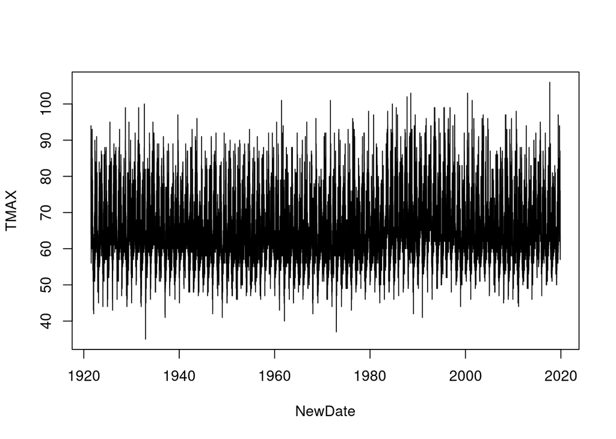

```r
strDates <- as.character(climate_data$DATE)
climate_data$NewDate <- as.Date(strDates, "%m/%d/%Y") ##reformatting dates - NewDate

## plot of daily TMAX data with correct and consisten date formatting
plot(TMAX~NewDate, climate_data, ty='l')
```

This shows us a much clearer plot of daily TMAX temperatures from 1920-2020. However, because this represents so much data compressed into one small graphic, its difficult to derive any meaning or trends from this plot.

```r
lm(TMAX ~ NewDate, data=climate_data)
```

```
##
## Call:
## lm(formula = TMAX ~ NewDate, data = climate_data)
##
## Coefficients:
## (Intercept)      NewDate
##   6.372e+01    5.835e-05
```

```r
summary(lm(TMAX ~ NewDate, data=climate_data))
```

```
##
## Call:
## lm(formula = TMAX ~ NewDate, data = climate_data)
##
## Residuals:
##     Min      1Q  Median      3Q     Max
## -27.929  -4.935  -0.867   3.795  41.265
##
## Coefficients:
##              Estimate Std. Error t value Pr(>|t|)
## (Intercept) 6.372e+01  4.010e-02  1588.8   <2e-16 ***
## NewDate     5.835e-05  3.865e-06    15.1   <2e-16 ***
## ---
## Signif. codes:  0 '***' 0.001 '**' 0.01 '*' 0.05 '.' 0.1 ' ' 1
##
## Residual standard error: 7.6 on 35926 degrees of freedom
##   (2 observations deleted due to missingness)
## Multiple R-squared:  0.006303,   Adjusted R-squared:  0.006275
## F-statistic: 227.9 on 1 and 35926 DF,  p-value: < 2.2e-16
```

Looking at this summary we see a slightly positive temperature slope (5.835e-05) which is highly significant. (The p-value is 2e-16, which is much less than 0.05). We see lots of variability that is not date driven. Therefore we reject the null hypothesis that there is a slope of 0 and a y-intercept of 0! While we have determined that the overall trend of TMAX is significantly positive, it could be more revealing of certain trends to break these graphics down into smaller sets of data. Below, the data will be broken down into monthly means of daily temperatures, first for the TMAX, then for TMIN:

```r
## disaggregate into month and year variables
climate_data$Month = format(as.Date(climate_data$NewDate), format = "%m")
climate_data$Year = format(climate_data$NewDate, format="%Y")

MonthlyTMAXMean = aggregate(TMAX ~ Month + Year, climate_data, mean)
MonthlyTMAXMean$YEAR = as.numeric(MonthlyTMAXMean$Year)
MonthlyTMAXMean$MONTH = as.numeric(MonthlyTMAXMean$Month)

str(MonthlyTMAXMean)
```

```
## 'data.frame':    1181 obs. of  5 variables:
##  $ Month: chr  "07" "08" "09" "10" ...
##  $ Year : chr  "1921" "1921" "1921" "1921" ...
##  $ TMAX : num  66.9 65.4 71.1 68.1 64.1 ...
##  $ YEAR : num  1921 1921 1921 1921 1921 ...
##  $ MONTH: num  7 8 9 10 11 12 1 2 3 4 ...
```

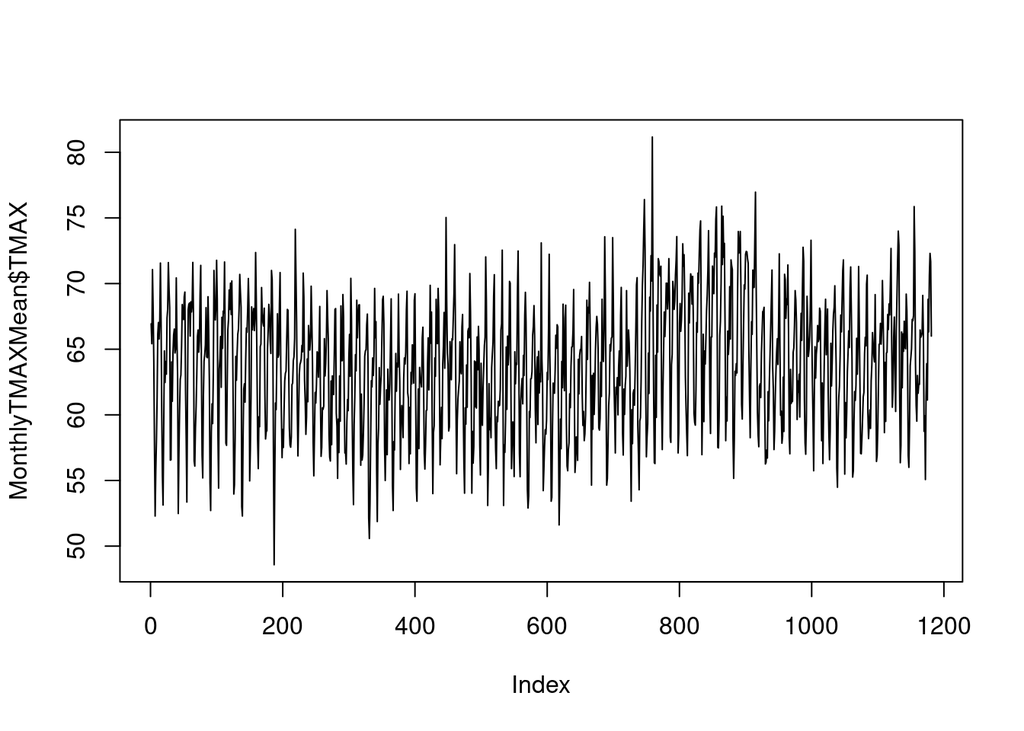

```r
plot(MonthlyTMAXMean$TMAX, ty='l')
```

```r
MonthlyTMINMean = aggregate(TMIN ~ Month + Year, climate_data, mean)
MonthlyTMINMean$YEAR = as.numeric(MonthlyTMINMean$Year)

MonthlyTMINMean$YEAR = as.numeric(MonthlyTMINMean$Year)
MonthlyTMINMean$MONTH = as.numeric(MonthlyTMINMean$Month)
head(MonthlyTMINMean)
```

```
##   Month Year     TMIN YEAR MONTH
## 1    07 1921 52.64516 1921     7
## 2    08 1921 53.67742 1921     8
## 3    09 1921 55.50000 1921     9
## 4    10 1921 54.87097 1921    10
## 5    11 1921 51.50000 1921    11
## 6    12 1921 48.09677 1921    12
```

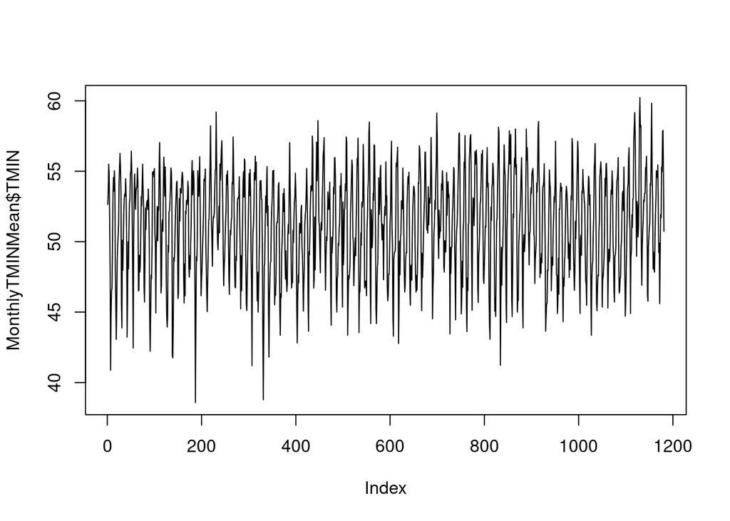

```r
plot(MonthlyTMINMean$TMIN, ty='l')
```

Next, we will look at the monthly averages of individual months over time:

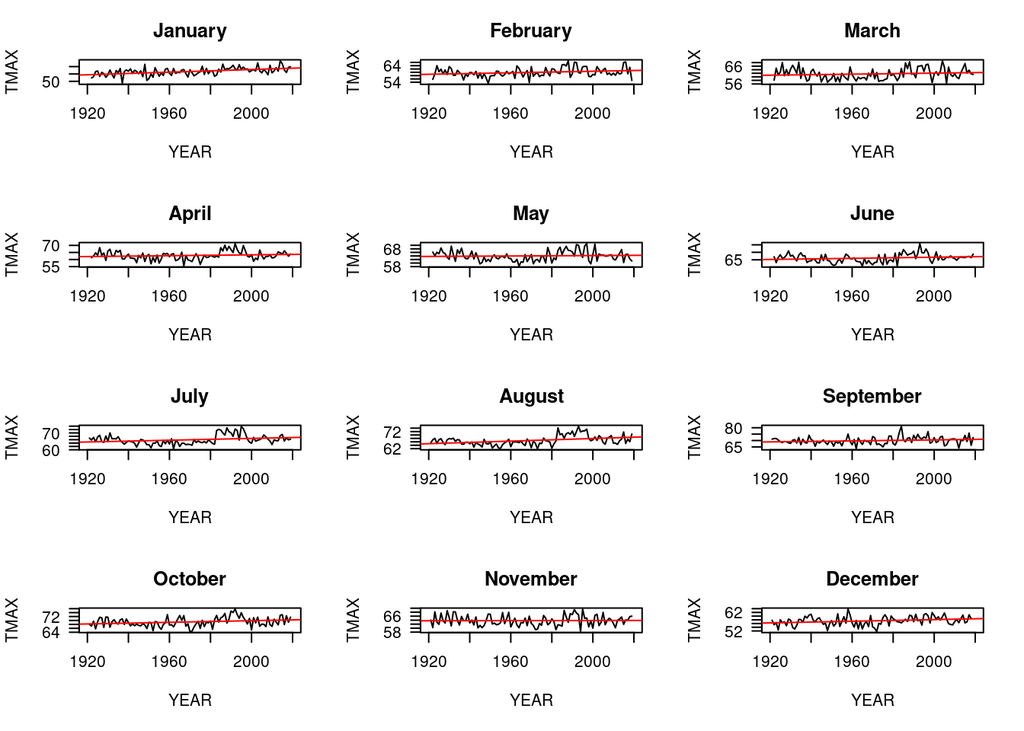

```r
Months = c("January", "February", "March", "April", "May", "June",
"July", "August", "September", "October", "November", "December")
# Create a panel so I can see all the figures at once.
par(mfrow=c(4,3), mar=c(5, 4, 3, 2) + 0.1)
TMAXresult <- NA
for (i in 1:12){
#plot(MonthlyTMAXMean£TMAX[MonthlyTMAXMean£Month==i], ty='l')
plot(TMAX~YEAR,
data=MonthlyTMAXMean[MonthlyTMAXMean$MONTH==i,],
ty='l', las=1, xlim=c(1920, 2020), main=Months[i])
Month.lm <- lm(TMAX~YEAR, data=MonthlyTMAXMean[MonthlyTMAXMean$MONTH==i,])
summary(Month.lm)
abline(coef(Month.lm), col="red")
TMAXresult <- rbind(TMAXresult,
cbind(Months[i], round(coef(Month.lm)[2], 4),
round(summary(Month.lm)$coefficients[2,4],4),
round(summary(Month.lm)$r.squared, 3)))
}
```

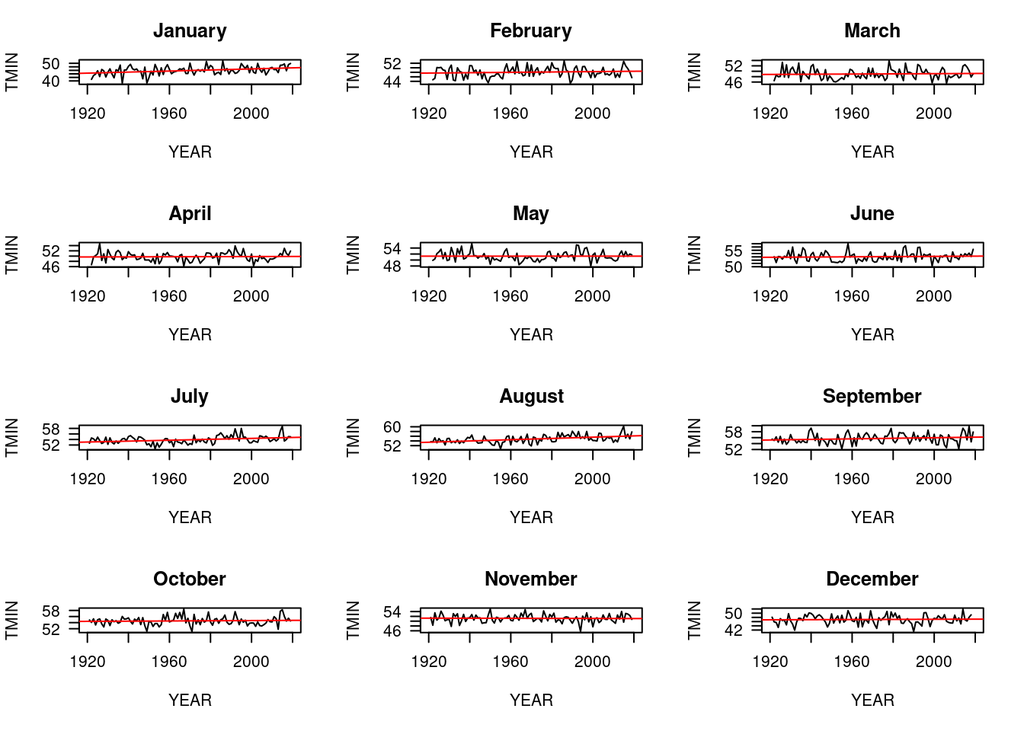

```r
par(mfrow=c(4,3), mar=c(5, 4, 3, 2) + 0.1)
TMINresult <- NA
for (i in 1:12){
#plot(MonthlyTMAXMean£TMAX[MonthlyTMINMean£Month==i], ty='l')
plot(TMIN~YEAR,
data=MonthlyTMINMean[MonthlyTMINMean$MONTH==i,],
ty='l', las=1, xlim=c(1920, 2020), main=Months[i])
Month.lm <- lm(TMIN~YEAR, data=MonthlyTMINMean[MonthlyTMINMean$MONTH==i,])
summary(Month.lm)
abline(coef(Month.lm), col="red")
TMINresult <- rbind(TMINresult,
cbind(Months[i], round(coef(Month.lm)[2], 4),
round(summary(Month.lm)$coefficients[2,4],4),
round(summary(Month.lm)$r.squared, 3)))
}
```

```r
##not sure how to expand the scale of the y axis! These don't look like much as is
```

```r
MonthlyTMINMean = aggregate(TMIN ~ Month + Year, climate_data, mean)
MonthlyTMINMean$YEAR = as.numeric(MonthlyTMINMean$Year)
# Fixing the Format of Month and Year as numeric
MonthlyTMINMean$YEAR = as.numeric(MonthlyTMINMean$Year)
MonthlyTMINMean$MONTH = as.numeric(MonthlyTMINMean$Month)
head(MonthlyTMINMean)
```

```
##   Month Year     TMIN YEAR MONTH
## 1    07 1921 52.64516 1921     7
## 2    08 1921 53.67742 1921     8
## 3    09 1921 55.50000 1921     9
## 4    10 1921 54.87097 1921    10
## 5    11 1921 51.50000 1921    11
## 6    12 1921 48.09677 1921    12
```

```r
## Makes a table
library(xtable)
Results <- data.frame(Month = TMINresult[c(2:13),1],
TMINSlope = TMINresult[c(2:13),2],
TMIN_P = as.numeric(TMINresult[c(2:13),3]),
TMINRsq = TMINresult[c(2:13),4],
TMAXSlope = TMAXresult[c(2:13),2],
TMAX_P = as.numeric(TMAXresult[c(2:13),3]),
TMAXRsq = TMAXresult[c(2:13),4])
Results$starTMIN = "NS"

## Shows which months are significant!
Results$starTMIN[Results$TMIN_P <= .05] = "*"
Results$starTMIN[Results$TMIN_P < 0.01] = "**"
Results$starTMIN[Results$TMIN_P < 0.001] = "***"
Results$starTMAX = "NS"
Results$starTMAX[Results$TMAX_P < 0.05] = "*"
Results$starTMAX[Results$TMAX_P < 0.01] = "**"
Results$starTMAX[Results$TMAX_P < 0.001] = "***"
Results$TMINslope=paste(Results$TMINSlope, Results$starTMIN)
Results$TMAXslope=paste(Results$TMAXSlope, Results$starTMAX)
colnames(Results) <- c("Month", "2", "3", "R^2", "5", "6",
"R^2", "8", "9", "Slope TMIN", "Slope TMAX")
print(xtable(Results[,c(1, 10, 4, 11, 7)]))
```

```
## % latex table generated in R 3.6.0 by xtable 1.8-4 package
## % Sun Dec 22 13:45:14 2019
## \begin{table}[ht]
## \centering
## \begin{tabular}{rlllll}
##   \hline
##  & Month & Slope TMIN & R\verb|^|2 & Slope TMAX & R\verb|^|2.1 \\
##   \hline
## 1 & January & 0.0301 *** & 0.122 & 0.0448 *** & 0.229 \\
##   2 & February & 0.008 NS & 0.01 & 0.0229 * & 0.056 \\
##   3 & March & 0.0035 NS & 0.003 & 0.0145 NS & 0.017 \\
##   4 & April & 0.0019 NS & 0.001 & 0.0151 NS & 0.02 \\
##   5 & May & 1e-04 NS & 0 & 0.0061 NS & 0.004 \\
##   6 & June & 0.0034 NS & 0.005 & 0.0188 NS & 0.036 \\
##   7 & July & 0.0165 *** & 0.111 & 0.0264 ** & 0.075 \\
##   8 & August & 0.0268 *** & 0.215 & 0.038 *** & 0.151 \\
##   9 & September & 0.0095 NS & 0.027 & 0.0196 NS & 0.037 \\
##   10 & October & 0.0033 NS & 0.005 & 0.0208 * & 0.061 \\
##   11 & November & -0.0017 NS & 0.001 & 0.0016 NS & 0 \\
##   12 & December & 0.003 NS & 0.002 & 0.0222 * & 0.067 \\
##    \hline
## \end{tabular}
## \end{table}
```

This shows us that the months January, July, and August are strongly significant in the rise of both their minimum and maximum temperature. Feburary, October, and December also show significant changes in their maximum temperature. Below there are larger graphics of the significant months of January, July, and August - first fro TMAX and then for TMIN:

```r
## January

plot(TMAX~YEAR, data=MonthlyTMAXMean[MonthlyTMAXMean$Month=="01",],
ty='l', xlim=c(1950, 2020))
January.lm <- lm(TMAX~YEAR, data=MonthlyTMAXMean[MonthlyTMAXMean$Month=="01",])
summary(January.lm)
```

```
##
## Call:
## lm(formula = TMAX ~ YEAR, data = MonthlyTMAXMean[MonthlyTMAXMean$Month ==
##     "01", ])
##
## Residuals:
##     Min      1Q  Median      3Q     Max
## -6.6428 -1.5843 -0.2245  1.5296  5.8649
##
## Coefficients:
##               Estimate Std. Error t value Pr(>|t|)
## (Intercept) -31.473738  16.507514  -1.907   0.0596 .
## YEAR          0.044758   0.008376   5.343 6.14e-07 ***
## ---
## Signif. codes:  0 '***' 0.001 '**' 0.01 '*' 0.05 '.' 0.1 ' ' 1
##
## Residual standard error: 2.346 on 96 degrees of freedom
## Multiple R-squared:  0.2292, Adjusted R-squared:  0.2212
## F-statistic: 28.55 on 1 and 96 DF,  p-value: 6.137e-07
```

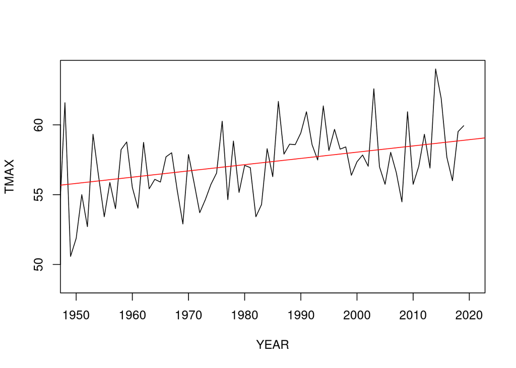

```r
abline(coef(January.lm), col="red")
```

```r
## July
plot(TMAX~YEAR, data=MonthlyTMAXMean[MonthlyTMAXMean$Month=="07",],
ty='l', xlim=c(1950, 2020))
July.lm <- lm(TMAX~YEAR, data=MonthlyTMAXMean[MonthlyTMAXMean$Month=="07",])
summary(July.lm)
```

```
##
## Call:
## lm(formula = TMAX ~ YEAR, data = MonthlyTMAXMean[MonthlyTMAXMean$Month ==
##     "07", ])
##
## Residuals:
##     Min      1Q  Median      3Q     Max
## -5.2249 -1.8191 -0.5002  1.4231  7.3548
##
## Coefficients:
##              Estimate Std. Error t value Pr(>|t|)
## (Intercept) 13.904058  18.587980   0.748  0.45626
## YEAR         0.026420   0.009435   2.800  0.00616 **
## ---
## Signif. codes:  0 '***' 0.001 '**' 0.01 '*' 0.05 '.' 0.1 ' ' 1
##
## Residual standard error: 2.683 on 97 degrees of freedom
## Multiple R-squared:  0.0748, Adjusted R-squared:  0.06526
## F-statistic: 7.842 on 1 and 97 DF,  p-value: 0.00616
```

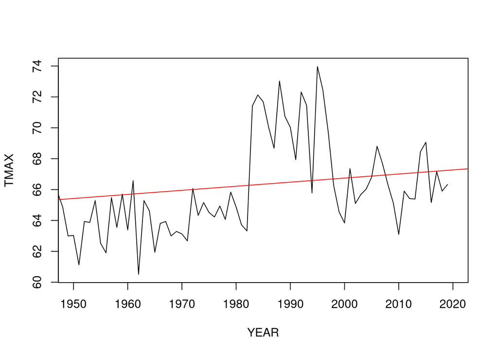

```r
abline(coef(July.lm), col="red")
```

```r
##August
plot(TMAX~YEAR, data=MonthlyTMAXMean[MonthlyTMAXMean$Month=="08",],
ty='l', xlim=c(1950, 2020))
August.lm <- lm(TMAX~YEAR, data=MonthlyTMAXMean[MonthlyTMAXMean$Month=="08",])
summary(August.lm)
```

```
##
## Call:
## lm(formula = TMAX ~ YEAR, data = MonthlyTMAXMean[MonthlyTMAXMean$Month ==
##     "08", ])
##
## Residuals:
##     Min      1Q  Median      3Q     Max
## -5.0847 -1.7490 -0.3958  1.5673  7.4454
##
## Coefficients:
##              Estimate Std. Error t value Pr(>|t|)
## (Intercept) -8.074746  18.004941  -0.448    0.655
## YEAR         0.038012   0.009139   4.160 6.89e-05 ***
## ---
## Signif. codes:  0 '***' 0.001 '**' 0.01 '*' 0.05 '.' 0.1 ' ' 1
##
## Residual standard error: 2.598 on 97 degrees of freedom
## Multiple R-squared:  0.1514, Adjusted R-squared:  0.1426
## F-statistic:  17.3 on 1 and 97 DF,  p-value: 6.893e-05
```

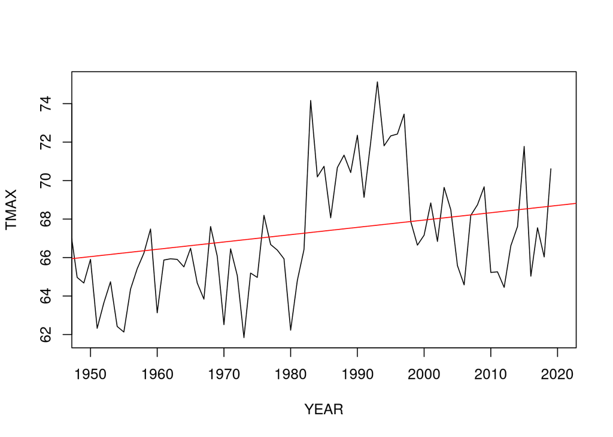

```r
abline(coef(August.lm), col="red")
```

```r
## January
plot(TMIN~YEAR, data=MonthlyTMINMean[MonthlyTMINMean$Month=="01",],
ty='l', xlim=c(1950, 2020))
January.lm <- lm(TMIN~YEAR, data=MonthlyTMINMean[MonthlyTMINMean$Month=="01",])
summary(January.lm)
```

```
##
## Call:
## lm(formula = TMIN ~ YEAR, data = MonthlyTMINMean[MonthlyTMINMean$Month ==
##     "01", ])
##
## Residuals:
##     Min      1Q  Median      3Q     Max
## -6.5076 -1.8122  0.1856  1.6429  5.0568
##
## Coefficients:
##              Estimate Std. Error t value Pr(>|t|)
## (Intercept) -13.34830   16.23815  -0.822 0.413095
## YEAR          0.03008    0.00824   3.651 0.000425 ***
## ---
## Signif. codes:  0 '***' 0.001 '**' 0.01 '*' 0.05 '.' 0.1 ' ' 1
##
## Residual standard error: 2.307 on 96 degrees of freedom
## Multiple R-squared:  0.1219, Adjusted R-squared:  0.1128
## F-statistic: 13.33 on 1 and 96 DF,  p-value: 0.0004255
```

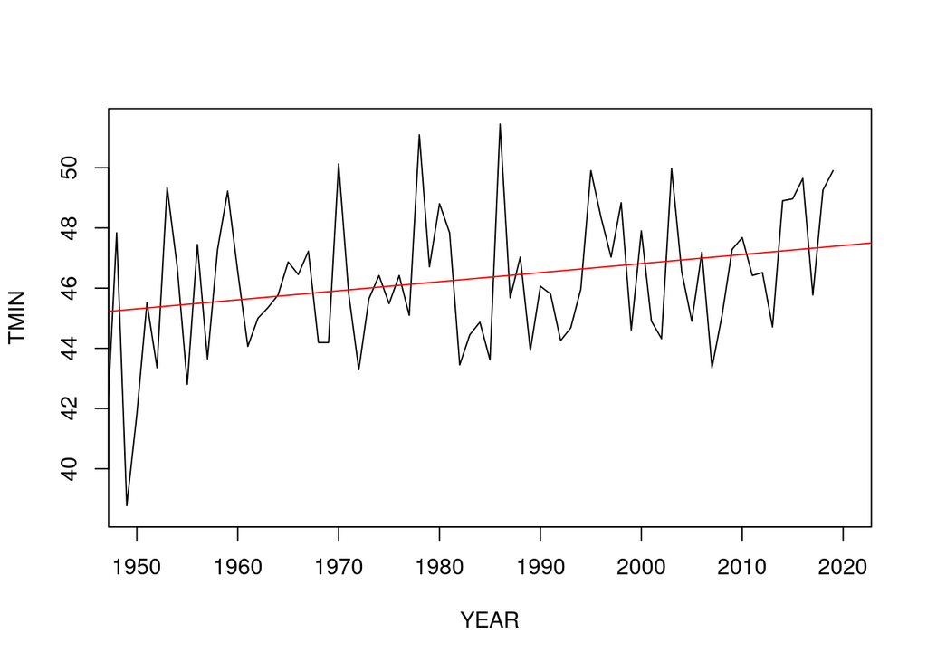

```r
abline(coef(January.lm), col="red")
```

```r
## July
plot(TMIN~YEAR, data=MonthlyTMINMean[MonthlyTMINMean$Month=="07",],
ty='l', xlim=c(1950, 2020))
July.lm <- lm(TMIN~YEAR, data=MonthlyTMINMean[MonthlyTMINMean$Month=="07",])
summary(July.lm)
```

```
##
## Call:
## lm(formula = TMIN ~ YEAR, data = MonthlyTMINMean[MonthlyTMINMean$Month ==
##     "07", ])
##
## Residuals:
##     Min      1Q  Median      3Q     Max
## -3.0323 -0.9165 -0.0554  0.8423  4.1406
##
## Coefficients:
##              Estimate Std. Error t value Pr(>|t|)
## (Intercept) 21.461506   9.309211   2.305 0.023274 *
## YEAR         0.016463   0.004725   3.484 0.000743 ***
## ---
## Signif. codes:  0 '***' 0.001 '**' 0.01 '*' 0.05 '.' 0.1 ' ' 1
##
## Residual standard error: 1.344 on 97 degrees of freedom
## Multiple R-squared:  0.1112, Adjusted R-squared:  0.1021
## F-statistic: 12.14 on 1 and 97 DF,  p-value: 0.0007426
```

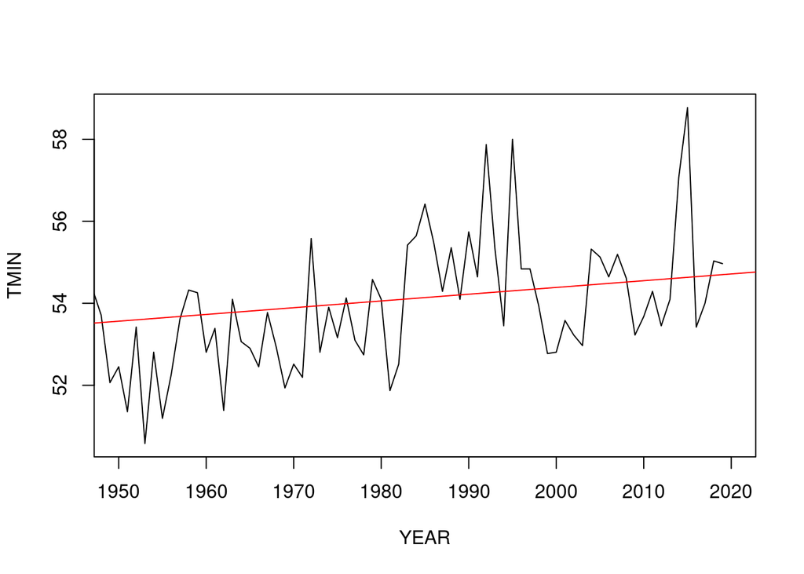

```r
abline(coef(July.lm), col="red")
```

```r
##August
plot(TMIN~YEAR, data=MonthlyTMINMean[MonthlyTMINMean$Month=="08",],
ty='l', xlim=c(1950, 2020))
August.lm <- lm(TMIN~YEAR, data=MonthlyTMINMean[MonthlyTMINMean$Month=="08",])
summary(August.lm)
```

```
##
## Call:
## lm(formula = TMIN ~ YEAR, data = MonthlyTMINMean[MonthlyTMINMean$Month ==
##     "08", ])
##
## Residuals:
##     Min      1Q  Median      3Q     Max
## -3.7772 -1.0142 -0.0739  1.2758  4.2278
##
## Coefficients:
##              Estimate Std. Error t value Pr(>|t|)
## (Intercept)  2.000972  10.249707   0.195    0.846
## YEAR         0.026798   0.005202   5.151 1.36e-06 ***
## ---
## Signif. codes:  0 '***' 0.001 '**' 0.01 '*' 0.05 '.' 0.1 ' ' 1
##
## Residual standard error: 1.479 on 97 degrees of freedom
## Multiple R-squared:  0.2148, Adjusted R-squared:  0.2067
## F-statistic: 26.53 on 1 and 97 DF,  p-value: 1.36e-06
```

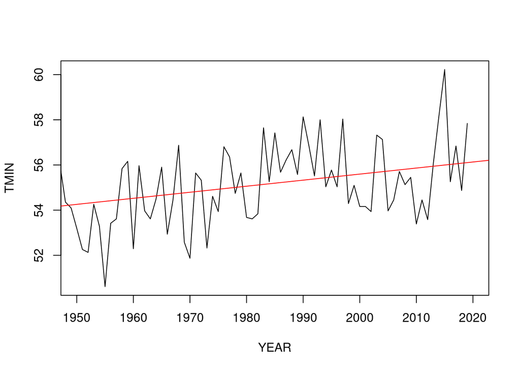

```r
abline(coef(August.lm), col="red")
```

From here we graph the monthly averages of each of the significant months across time, both for maximum temperature and minimum temperature. Each one of these months show a positive trend both in their minimun and maximum temperatures.

## Analysis/Conclusion

The trends in the data from NOAA showed a significant rising in minimum and maximum temperatures during months January, August, and July. This is consistent with literature I’ve found with predicted impacts on the area. Berkeley News listed several effects that San Francisco residents may be experiencing, such as - an increase in average annual maximum temperature of 1.7°F since 1950 - less frequent coastal fog - An 8 inch sea level rise in the Bay in the last 100 years; The 2012-2016 drought drove statewide moisture levels to the lowest in more than 1,000 years and left a snowpack lower than seen in 500 years;

News coverage has already begun to cover stories of flooding along the roadways along the Embarcadero, and projections predict "SAN FRANCISCO (KGO) – King Tides combined with a strong storm to cause flooding along the Embarcadero in San Francisco Tuesday morning.

City crews closed one lane of the waterfront roadway because of backed up storm drains.

Drivers found themselves rolling through large puddles when the tide peaked around 9 a.m."

## References

Aragon, Greg. “San Francisco Begins Fortification Process of 100-Year-Old Seawall.” Engineering NewsRecord RSS, Engineering News-Record, 16 May 2016, www.enr.com/blogs/12-california-views/post/39403-san-francisco-begins-fortification-process-of-100-year-old-seawall.

Kgo. “King Tides Cause Flooding along San Francisco Embarcadero during Strong Storm.” ABC7 San Francisco, 10 Jan. 2017, abc7news.com/weather/king-tides-cause-flooding-along-san-francisco-embarcadero/1695830/.

Rogers, Paul. “The $5 Billion Plan to Save San Francisco from Flooding in a Major Earthquake.” The Mercury News, The Mercury News, 22 Oct. 2018, www.mercurynews.com/2018/10/18/seawall/.

Sanders, Robert. “UC Berkeley Leads New Assessment of Bay Area Climate Impacts.” Berkeley News, 29 Aug. 2018, news.berkeley.edu/2018/08/27/uc-berkeley-leads-new-assessment-of-bay-area-climate-impacts/.

Sanders, Robert. “UC Berkeley Leads New Assessment of Bay Area Climate Impacts.” Berkeley News, 29 Aug. 2018, news.berkeley.edu/2018/08/27/uc-berkeley-leads-new-assessment-of-bay-area-climate-impacts/.

Wolff, Matt, and Cynthia Comerford. “San Francisco Climate & Health Profile.” San Francisco Department of Public Health, 2014.